# Laboratorio 1 - Econometría en R - Rodolfo Zea

```r
library(ggplot2)
library(dplyr)
library(corrplot)
```

Cargamos el archivo “Admission_Predict_Ver1.1.csv” que se utiliza como fuente de datos para el presente laboratorio.

```r
dataset <- read.csv("Admission_Predict_Ver1.1.csv")
```

1. Realice un análisis estadístico sobre todas las variables del dataset, recuerde que pude usar la función summary()

Variable Serial No.:

```r
summary(dataset$Serial.No.)
```

```
##    Min. 1st Qu.  Median    Mean 3rd Qu.    Max.
##     1.0   125.8   250.5   250.5   375.2   500.0
```

Variable GRE.Score:

```r
summary(dataset$GRE.Score)
```

```
##    Min. 1st Qu.  Median    Mean 3rd Qu.    Max.
##   290.0   308.0   317.0   316.5   325.0   340.0
```

Variable TOEFL.Score:

```r
summary(dataset$TOEFL.Score)
```

```
##    Min. 1st Qu.  Median    Mean 3rd Qu.    Max.
##    92.0   103.0   107.0   107.2   112.0   120.0
```

Variable University.Rating:

```r
summary(dataset$University.Rating)
```

```
##    Min. 1st Qu.  Median    Mean 3rd Qu.    Max.
##   1.000   2.000   3.000   3.114   4.000   5.000
```

Variable SOP:

```r
summary(dataset$SOP)
```

```
##    Min. 1st Qu.  Median    Mean 3rd Qu.    Max.
##   1.000   2.500   3.500   3.374   4.000   5.000
```

Variable LOR:

```r
summary(dataset$LOR)
```

```
##    Min. 1st Qu.  Median    Mean 3rd Qu.    Max.
##   1.000   3.000   3.500   3.484   4.000   5.000
```

Variable CGPA:

```r
summary(dataset$CGPA)
```

```
##    Min. 1st Qu.  Median    Mean 3rd Qu.    Max.
##   6.800   8.127   8.560   8.576   9.040   9.920
```

Variable Research:

```r
summary(dataset$Research)
```

```
##    Min. 1st Qu.  Median    Mean 3rd Qu.    Max.
##    0.00    0.00    1.00    0.56    1.00    1.00
```

Variable Chance.Of.Admit:

```r
summary(dataset$Chance.of.Admit)
```

```
##    Min. 1st Qu.  Median    Mean 3rd Qu.    Max.
##  0.3400  0.6300  0.7200  0.7217  0.8200  0.9700
```

2. Realice una gráfica de histograma o densidad para cada una de las variable numéricas: GRE.Score, TOEFEL.Score, CGPA y Chance of Admit

Variable GRE.Score

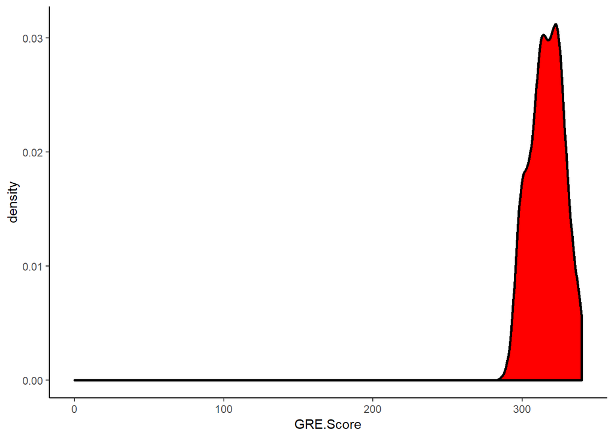

```r
dataset %>%
  ggplot(aes(x=GRE.Score, y=..density..)) +
  geom_density(fill="red", lwd=1) +
  theme_classic() +
  xlim(0,340)
```

Variable TOEFL.Score

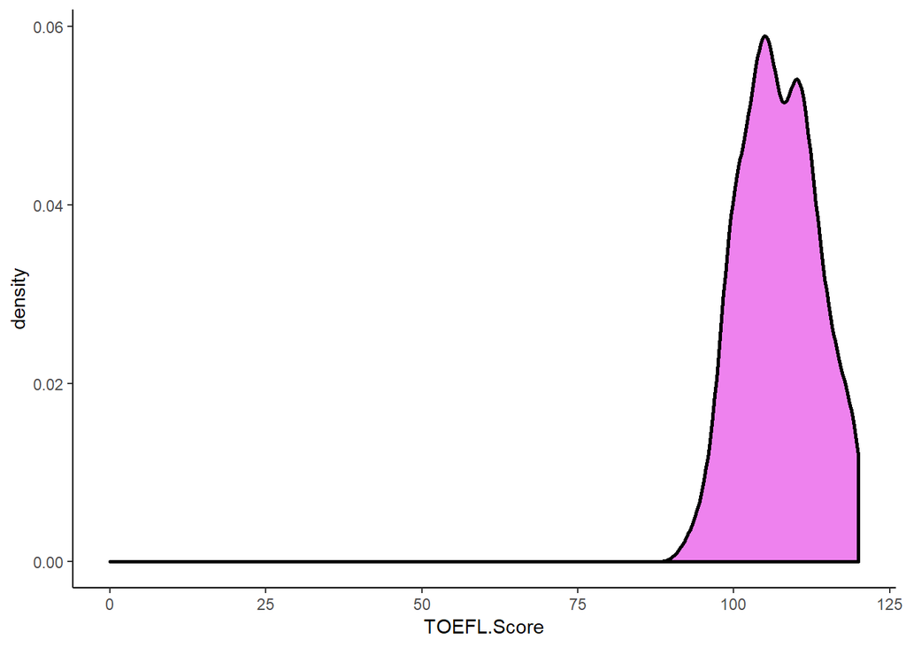

```r
dataset %>%
  ggplot(aes(x=TOEFL.Score, y=..density..)) +
  geom_density(fill="violet", lwd=1) +
  theme_classic() +
  xlim(0,120)
```

Variable CGPA

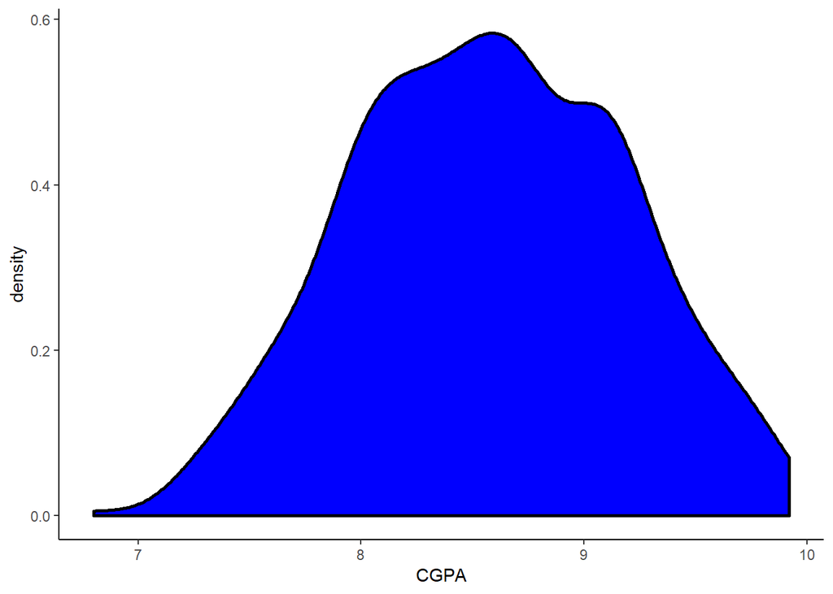

```r
dataset %>%
  ggplot(aes(x=CGPA, y=..density..)) +
  geom_density(fill="blue", lwd=1) +
  theme_classic() +
  xlim(6.800,9.920)
```

Variable Chance.of.Admit

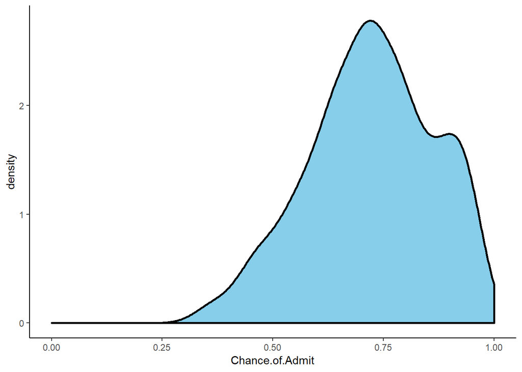

```r
dataset %>%
  ggplot(aes(x=Chance.of.Admit, y=..density..)) +
  geom_density(fill="skyBlue", lwd=1) +
  theme_classic() +
  xlim(0,1)
```

3. Realice una gráfica de correlación entre las variables del inciso 2.

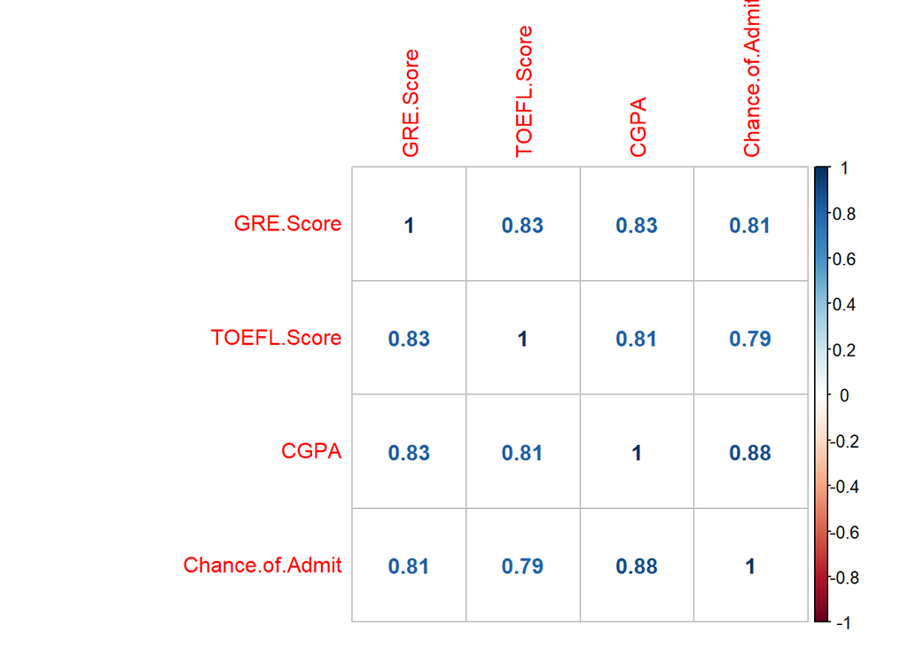

```r
datasetInteres <- select(dataset, GRE.Score, TOEFL.Score, CGPA, Chance.of.Admit)
correlacion <- cor(datasetInteres)
corrplot(correlacion, method="number")
```

4. Realice comentarios sobre el análisis estadístico de las variables numéricas

Como es posible observar, todas las variables numéricas tienen alto grado de correlación positiva, esto quiere decir que, por cada par de variables seleccionadas, al momento que una de ellas cambie su valor, la otra también cambiará en la misma dirección que lo hizo la primera. Para el caso de las variables numéricas seleccionadas, casi todas cambian en una medida muy similar a la variable en comparación, esto puesto que el coeficiente de correlación es muy cercano a uno.

5. Realice un scatter plot de todas las variables numéricas contra la variable Chance of Admit

Variable GRE.Score:

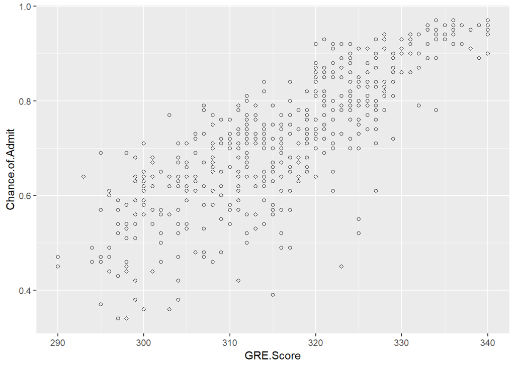

```r
ggplot(dataset, aes(x=GRE.Score, y=Chance.of.Admit)) +
    geom_point(shape=1)
```

Variable TOEFL.Score:

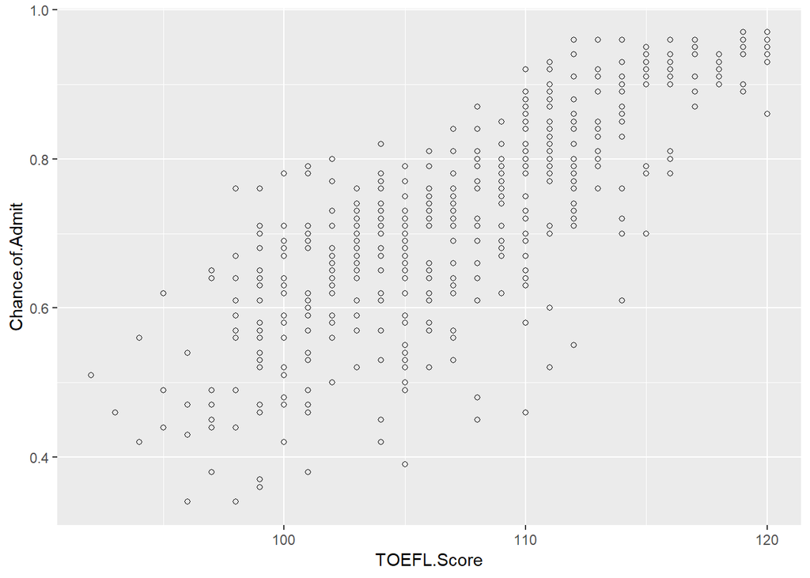

```r
ggplot(dataset, aes(x=TOEFL.Score, y=Chance.of.Admit)) +
    geom_point(shape=1)
```

Variable CGPA:

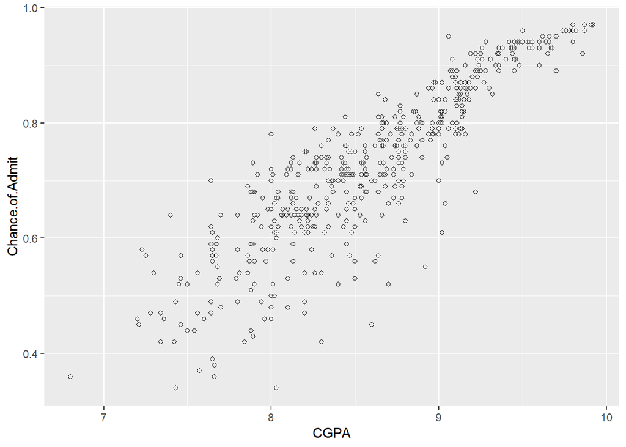

```r
ggplot(dataset, aes(x=CGPA, y=Chance.of.Admit)) +
    geom_point(shape=1)
```

6. Realice un modelo de regresión lineal simple con cada variable numéreica como X y la variable Chance of Admit como Y

Variable GRE.Score:

```r
modeloGREScore<-lm(data = dataset,
                    formula = Chance.of.Admit ~ GRE.Score)

modeloGREScore
```

```
##
## Call:
## lm(formula = Chance.of.Admit ~ GRE.Score, data = dataset)
##
## Coefficients:
## (Intercept)    GRE.Score
##    -2.48281      0.01013
```

Variable TOEFL.Score:

```r
modeloTOEFLScore<-lm(data = dataset,
                    formula = Chance.of.Admit ~ TOEFL.Score)

modeloTOEFLScore
```

```
##
## Call:
## lm(formula = Chance.of.Admit ~ TOEFL.Score, data = dataset)
##
## Coefficients:
## (Intercept)  TOEFL.Score
##    -1.24899      0.01839
```

Variable CGPA:

```r
modeloCGPA<-lm(data = dataset,
                    formula = Chance.of.Admit ~ CGPA)

modeloCGPA
```

```
##
## Call:
## lm(formula = Chance.of.Admit ~ CGPA, data = dataset)
##
## Coefficients:
## (Intercept)         CGPA
##     -1.0443       0.2059
```

7. Realice una gráfica de cada modelo de regresión lineal en su scatter plot correspondiente.

Variable GRE.Score:

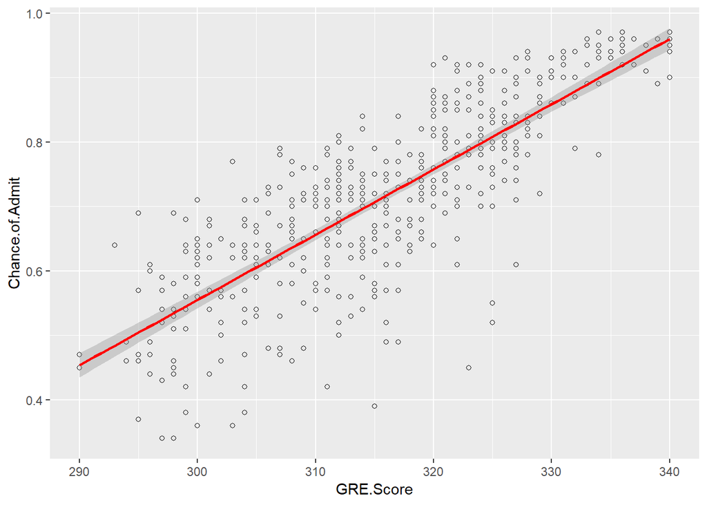

```r
ggplot(dataset, aes(x=GRE.Score, y=Chance.of.Admit)) +
    geom_point(shape=1) +
    stat_smooth(method = "lm", col="red")
```

Variable TOEFL.Score:

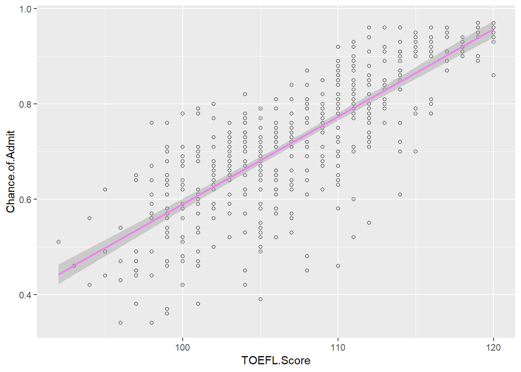

```r
ggplot(dataset, aes(x=TOEFL.Score, y=Chance.of.Admit)) +
    geom_point(shape=1) +
    stat_smooth(method = "lm", col="violet")
```

Variable CGPA:

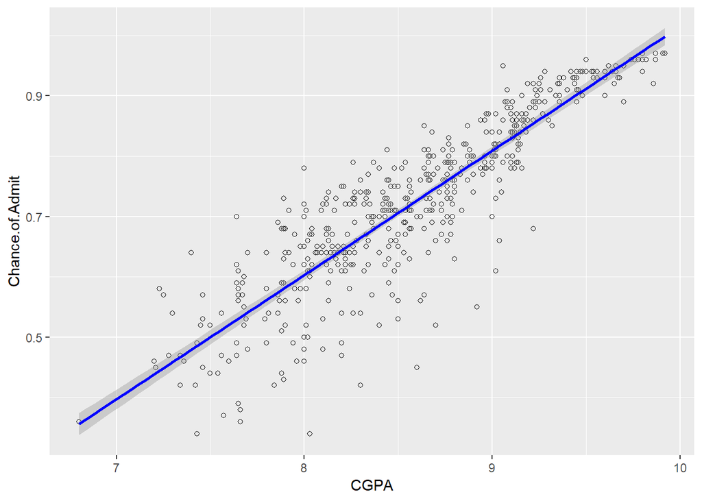

```r
ggplot(dataset, aes(x=CGPA, y=Chance.of.Admit)) +
    geom_point(shape=1) +
    stat_smooth(method = "lm", col="blue")
```

8. Realice un análisis sobre los resultados de cada modelo y diga cual de éstos considera que es mejor y por qué.

Variable GRE.Score:

```r
summary(modeloGREScore)
```

```
##
## Call:
## lm(formula = Chance.of.Admit ~ GRE.Score, data = dataset)
##
## Residuals:
##      Min       1Q   Median       3Q      Max
## -0.33784 -0.04479  0.00417  0.05449  0.18568
##
## Coefficients:
##               Estimate Std. Error t value Pr(>|t|)
## (Intercept) -2.4828147  0.1038994  -23.90   <2e-16 ***
## GRE.Score    0.0101259  0.0003281   30.86   <2e-16 ***
## ---
## Signif. codes:  0 '***' 0.001 '**' 0.01 '*' 0.05 '.' 0.1 ' ' 1
##
## Residual standard error: 0.08278 on 498 degrees of freedom
## Multiple R-squared:  0.6567, Adjusted R-squared:  0.656
## F-statistic: 952.5 on 1 and 498 DF,  p-value: < 2.2e-16
```

Análisis de los residuos:

Los residuos indican la diferencia entre el valor observado y el valor que el modelo predice. En este caso, es posible observar que los residuos se encuentran en un rango entre -0.33784 y 0.18568 que son bastante pequeños en proporción a los valores de las mediciones. La mediana de los residuos es 0.00417, podemos ver que existe cierto sesgo a la izquierda.

Análisis de los coeficientes: Podemos ver que tanto para el intercepto, como para el aproximado para el coeficiente para GRE.Score, el error estándar es bastante pequeño en comparación al valor de su estimado (valor esperado). Vemos que el valor de t es bastante grande y alejado de 0 y que el valor de Pr(>t), que es la probabilidad de observar un valor igual o mayor a t, es pequeñisimo.

El error estándar de los residuos es bastante bajo (0.08278), por lo que podemos decir que el modelo de regresión lineal encaja bastante bien con los datos.

Analizando el coeficiente de determinación podemos ver que tiene un valor de 0.6567 que nos indica que la linea de regresión del modelo no se ajusta tan bien, como se esperaría, a los datos observados. Esto considerando que el valor mínimo es 0 y el valor máximo 1. Es importante recalcar que un valor de 1 no indica que sea el mejor modelo, puesto que estaría ajustado de más.

Podemos apreciar que el estadístico de F es bastante mayor a uno y por consiguiente podemos decir que sí hay una relación entre la variable GRE.Score y Chance.of.Admit.

Variable TOEFL.Score:

```r
summary(modeloTOEFLScore)
```

```
##
## Call:
## lm(formula = Chance.of.Admit ~ TOEFL.Score, data = dataset)
##
## Residuals:
##      Min       1Q   Median       3Q      Max
## -0.31337 -0.04990  0.01310  0.05633  0.20725
##
## Coefficients:
##               Estimate Std. Error t value Pr(>|t|)
## (Intercept) -1.2489882  0.0681317  -18.33   <2e-16 ***
## TOEFL.Score  0.0183850  0.0006346   28.97   <2e-16 ***
## ---
## Signif. codes:  0 '***' 0.001 '**' 0.01 '*' 0.05 '.' 0.1 ' ' 1
##
## Residual standard error: 0.08621 on 498 degrees of freedom
## Multiple R-squared:  0.6276, Adjusted R-squared:  0.6269
## F-statistic: 839.4 on 1 and 498 DF,  p-value: < 2.2e-16
```

Análisis de los residuos:

Los residuos indican la diferencia entre el valor observado y el valor que el modelo predice. En este caso, es posible observar que los residuos se encuentran en un rango entre -0.31337 y 0.20725 que son bastante pequeños en proporción a los valores de las mediciones. La mediana de los residuos es 0.01310, bastante cerca del centro del rango.

El error estándar de los residuos es bastante bajo (0.08621), por lo que podemos decir que el modelo de regresión lineal encaja bastante bien con los datos.

Analizando el coeficiente de determinación podemos ver que tiene un valor de 0.6276 que nos indica que la linea de regresión del modelo no se ajusta tan bien, como se esperaría, a los datos observados. Esto considerando que el valor mínimo es 0 y el valor máximo 1. Es importante recalcar que un valor de 1 no indica que sea el mejor modelo, puesto que estaría ajustado de más.

Variable CGPA:

```r
summary(modeloCGPA)
```

```
##
## Call:
## lm(formula = Chance.of.Admit ~ CGPA, data = dataset)
##
## Residuals:
##       Min        1Q    Median        3Q       Max
## -0.276592 -0.028169  0.006619  0.038483  0.176961
##
## Coefficients:
##             Estimate Std. Error t value Pr(>|t|)
## (Intercept) -1.04434    0.04230  -24.69   <2e-16 ***
## CGPA         0.20592    0.00492   41.85   <2e-16 ***
## ---
## Signif. codes:  0 '***' 0.001 '**' 0.01 '*' 0.05 '.' 0.1 ' ' 1
##
## Residual standard error: 0.06647 on 498 degrees of freedom
## Multiple R-squared:  0.7787, Adjusted R-squared:  0.7782
## F-statistic:  1752 on 1 and 498 DF,  p-value: < 2.2e-16
```

Análisis de los residuos:

Los residuos indican la diferencia entre el valor observado y el valor que el modelo predice. En este caso, es posible observar que los residuos se encuentran en un rango entre -0.276592 y 0.176961 que son bastante pequeños en proporción a los valores de las mediciones. La mediana de los residuos es 0.006619, bastante cerca del centro del rango.

El error estándar de los residuos es bastante bajo (0.06647), por lo que podemos decir que el modelo de regresión lineal encaja bastante bien con los datos.

Analizando el coeficiente de determinación podemos ver que tiene un valor de 0.7787 que nos indica que la linea de regresión del modelo se ajusta bastante bien a los datos observados. Esto considerando que el valor mínimo es 0 y el valor máximo 1. Es importante recalcar que un valor de 1 no indica que sea el mejor modelo, puesto que estaría ajustado de más.

CONCLUSIÓN:

Podemos concluir que el modelo que mejor se apega es el obtenido a partir de la variable independiente CGPA, esto debido a que el coeficiente de determinación es el más alto (no estando demasiado cerca de 1, sino a un valor bastante razonable), el error estandar residual es el menor de los tres modelos y el estadístico de F es bastante alto.